# Impacts of not sampling d2m every year in every refuge

Emilio A. Laca

11/10/2021

## Introduction

WHAP measures linear dimensions of seed heads in the field but attempts to estimate mass of seedheads produced. Dimensions-to-mass (d2m) models are developed and used to transform linear dimensions to estimated mass of seed heads. Then, number of seedheads per unit area and average seed head dimensions are used to estimate mass of seed heads per unit area in each of the abundance strata (low, medium and high) for each species.

Is it necessary to create a different d2m model for each location and year or is it sufficient to create one model that is applicable over refuges and years? Of course, this question can only be answered for past years and observed locations. One can assume that differences (or lack of differences) persist into the future and decide this once and for all or one can continue to test over time. This document is about exploring the answer to the question using data about seed head dimensions and mass collected in several refuges in 2019 and in Modoc in 2021.

## Data

```
##  [1] "CLS"        "KRN"        "PXL"        "SAC"        "STL"
##  [6] "PIX"        "SL_"        "Colusa"     "Sacramento" "StoneLakes"
## [11] "MDC"
```

## Approach and functions

We have data for Swamp Timothy in six, and for Watergrass in four, different combinations of locations and years. No refuge was sampled more than once to create d2m models. Thus, the variation among groups is mostly spatial. There is no data to estimate the possible variation within a refuge among years.

We should keep in mind that the uncertainty due to these models is NOT incorporated in the final mass estimates in the current protocol. Thus, the effect of choice of approach on precision is mostly invisible.

With these data we have the following options:

1. Collect d2m data for each new LIT_yr group. Augment the data base and create a model that always includes effects of all LIT_yr groups ever observed. Always make group-specific predictions whose uncertainty excludes the variance of random effects.

The performance of this option is assessed with the present data by k-fold cross-validation with folds balanced by groups.

2. Take all d2m data and create a model that includes effects of LIT_yr groups. No more data about d2m are collected and this model is not updated. Except for the LIT_yr groups present in the data, predictions are made at the population level and random effect variances contribute to the uncertainty of estimates.

The performance of this option is assessed with the present data by leaving each group out at a time, developing the model with the rest of the groups and using it in the group left out.

Three metrics are used to assess the performance of the options:

1. Means absolute deviation (mae) is a measure of accuracy and error.
2. Root mean squared error (rmse) is a measure of accuracy and total error.
3. R squared (rsq) is the square of the correlation between observed and predicted values and it is a measure of consistency.

Predictions that deviate from observed values in a linear relationship can have very large rsq (good) and also large rsme (bad). If the slope of the relationship is null the bias is constant over X. If the slope is different from 0, the bias changes as X changes.

### Function to evaluate options

### Function to summarize results of each evaluation

This function takes the list created by the previous function, summarizes and plots results.

```r
# Swam Timothy
st_model_eval <- model_eval_fnc(the_data = st_d2m)
st_rslts <- summarize_plot_fnc(rslt_list = st_model_eval)

# Watergrass
wg_model_eval <- model_eval_fnc(the_data = wg_d2m)
wg_rslts <- summarize_plot_fnc(rslt_list = wg_model_eval)
```

### Swamp Timothy graphical results

```
## [1] "SWAMP TIMOTHY PREDICTIONS FOR SAMPLED REFUGES"
```

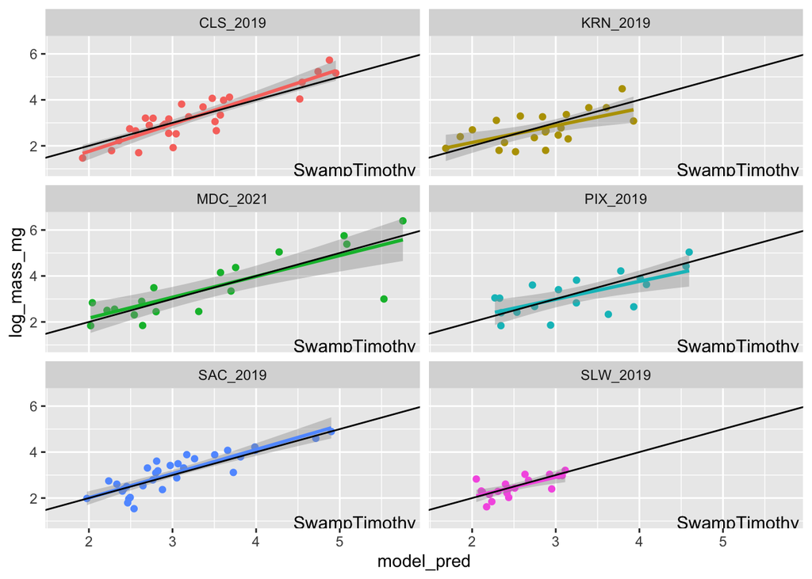

```
## [1] "SWAMP TIMOTHY PREDICTIONS FOR NEW REFUGES"
```

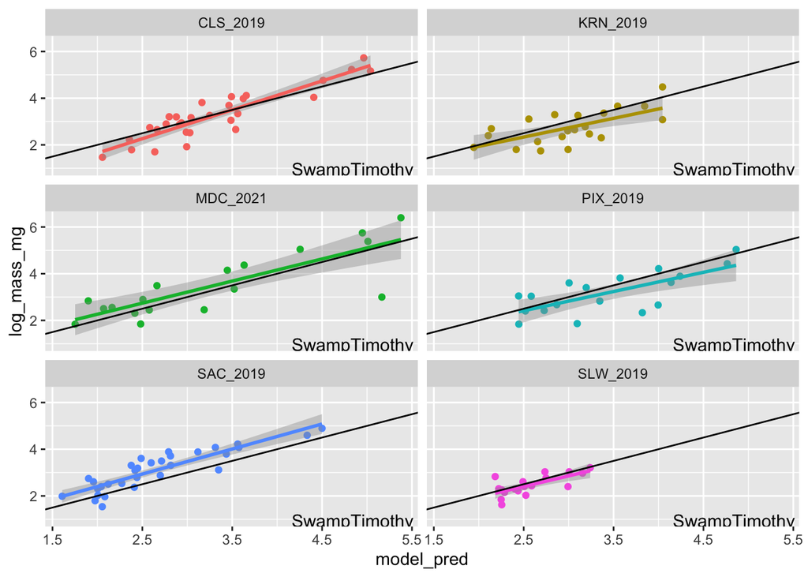

### Swamp Timothy metrics

Table of cross validation results for SwampTimothy. These results represent how well the model performs when all groups have data for d2m.

| id | rmse | rsq | mae |
| --- | --- | --- | --- |
| Fold1 | 0.569 | 0.798 | 0.508 |
| Fold2 | 0.708 | 0.537 | 0.493 |
| Fold3 | 0.480 | 0.728 | 0.380 |
| Fold4 | 0.525 | 0.749 | 0.450 |
| Fold5 | 0.515 | 0.683 | 0.391 |
| Fold6 | 0.460 | 0.746 | 0.350 |
| Average | 0.543 | 0.707 | 0.429 |

Table of final validation results for SwampTimothy when data for each refuge is kept out from model creation and used for final testing. This test provides a realistic estimate of the error expected when using data from an observed set of refuge-year combinations to predict seed head mass in a new refuge-year.

| grp_out | rmse | rsq | mae |
| --- | --- | --- | --- |
| CLS_2019 | 0.478 | 0.824 | 0.386 |
| KRN_2019 | 0.600 | 0.436 | 0.508 |
| MDC_2021 | 0.790 | 0.679 | 0.635 |
| PIX_2019 | 0.663 | 0.524 | 0.527 |
| SAC_2019 | 0.598 | 0.782 | 0.518 |
| SLW_2019 | 0.314 | 0.534 | 0.233 |
| Average | 0.574 | 0.630 | 0.468 |

### Watergrass graphical results

```
## [1] "WATERGRASS PREDICTIONS FOR SAMPLED REFUGES"
```

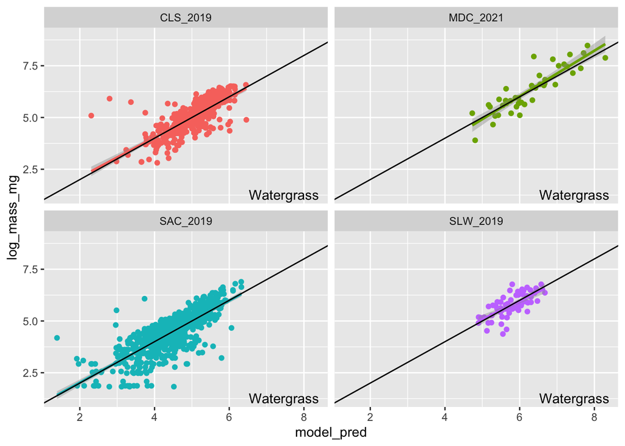

```
## [1] "WATERGRASS PREDICTIONS FOR NEW REFUGES"
```

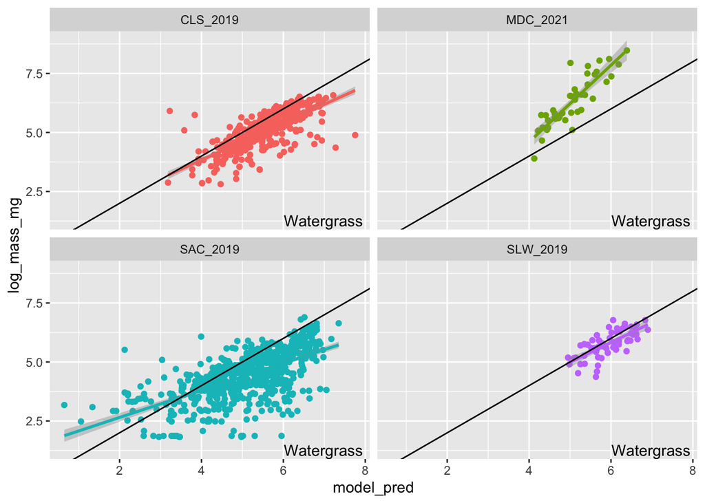

### Watergrass metrics

Table of cross validation results for Watergrass. These results represent how well the model performs when all groups have data for d2m.

| id | rmse | rsq | mae |
| --- | --- | --- | --- |
| Fold1 | 0.590 | 0.616 | 0.418 |
| Fold2 | 0.546 | 0.691 | 0.403 |
| Fold3 | 0.544 | 0.754 | 0.405 |
| Fold4 | 0.577 | 0.733 | 0.431 |
| Fold5 | 0.558 | 0.729 | 0.425 |
| Fold6 | 0.623 | 0.656 | 0.437 |
| Average | 0.573 | 0.696 | 0.420 |

Table of final validation results for Watergrass when data for each refuge is kept out from model creation and used for final testing. This test provides a realistic estimate of the error expected when using data from an observed set of refuge-year combinations to predict seed head mass in a new refuge-year.

| grp_out | rmse | rsq | mae |
| --- | --- | --- | --- |
| CLS_2019 | 0.739 | 0.551 | 0.563 |
| MDC_2021 | 1.404 | 0.760 | 1.268 |
| SAC_2019 | 1.132 | 0.387 | 0.861 |
| SLW_2019 | 0.435 | 0.517 | 0.340 |
| Average | 0.927 | 0.554 | 0.758 |